# trauma and conflict risks

Hertie, October 2026

Macartan Humphreys

# The question

Can psycho-social accounts explain conflict cycles (and what can be done about it)?

## Can psycho-social accounts explain conflict cycles (and what can be done about it)?

- Conflicts do seem to re-occur
- Conflict exposure can have enormous psychological effects on features that could themselves matter for between group relations
- The question is whether distress, threat perceptions, or other psychological orientations can explain the wars that come back.

## Can psycho-social accounts explain cycles?

The macro literature does **not** provide initial support for the idea:

- Civil wars do recur. Between 1945 and 1996, 36 percent of civil wars were followed by another war (Walter 2004). But:

> renewed war is likely to have less to do with the attributes of a previous war […] than with current incentives individual citizens have to rejoin a rebel group

And:

- More deadly wars: **not** associated with reoccurrence
- Longer wars: **reduced** likelihood of reoccurrence

## Can psycho-social accounts explain cycles?

Much of the macro literature does not really think about psychology at all

[figure not shown]

## Exposure and militancy

On the other hand a *lot* of **micro** evidence suggests possible pathways:

- Gábor Máté accounts of psychological effects and suggestions about these scaling (Pierre Boulez Saal 2024)
- Hirsch-Hoefler et al. (2016) find that **exposure to political violence** makes Israelis and Palestinians **less likely to support peace efforts**
- Hadzic et al. (2020) find that communities with more **wartime casualties** gave more support to **ethnic parties**
- Grossman et al. (2015) show that for Israeli soldiers of the Second Intifada, **combat** is associated with a **less conciliatory index**, about $-0.3$ standard deviations, and with more hawkish voting (and credible design).

## Exposure and militancy

- MacManus et al. (2013) show among UK personnel, post-deployment PTSD is associated with subsequent violent offending.
- Taylor et al. (2020) use a meta-analysis of ten observational studies to show higher odds of violent arrest among veterans with PTSD, about 1.6

Complex patterns:

- Lindsey (2022) finds that exposure to armed violence in eastern Congo raises support for punishment for rape and lowers it for domestic violence (protective masculine norms)

Contrary logics?

- Also: Lindsey and Koos (2025) find that households of survivors of wartime sexual violence in eastern Congo do more social and political activity, not less (related to stigma, self-blame, and reconnection).

## Famine effects

Narciso and Severgnini (2023) link family exposure to the Great Irish Famine, 1845–50, to participation in the Irish Revolution, 1916–21

- A one percent higher potato-crop failure rate in the county of birth raises the probability of being a rebel by 0.033 percentage points.
- A one percent higher excess mortality is associated with about 0.33 percentage points.

They track surnames, and they instrument blight with wind direction.

- Socio-cultural persistence? Something deeper?

## Major theme of this talk

1. Something of a convergence on the micro side:
- Exposure to wartime violence leaves political traces.
- However, they are small, and they are specific to the parties and groups of that war.
2. Multiple imaginable mechanisms
3. Interventions in this space (not always theory informed)
4. Micro-macro linkages missing

given the rich work that exists and importance of the topic, this should be a priority

## A map

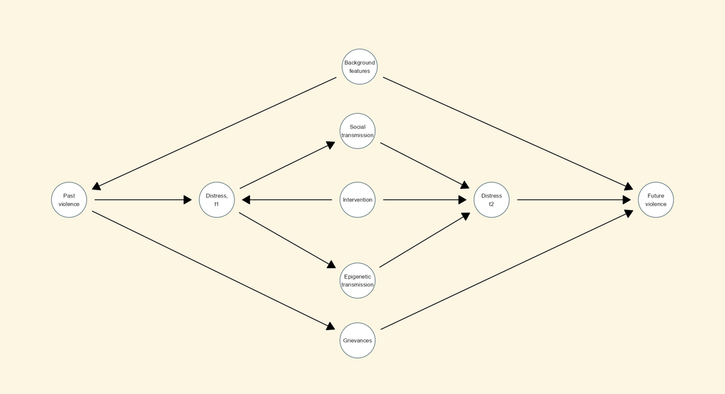

# What the evidence shows

## Positive effects of exposure to violence?

Bauer et al. (2016) concluded that although the human costs of war are horrific, there are reasons for optimism once the violence ends.

> In case after case, people exposed to war violence go on to behave more cooperatively and altruistically, which we will generally call “prosocial” behavior.

(based on review of 23 papers)

They also note that the prosocial pattern may be strongest inside the village or the identity group.

## Cooperation after violence

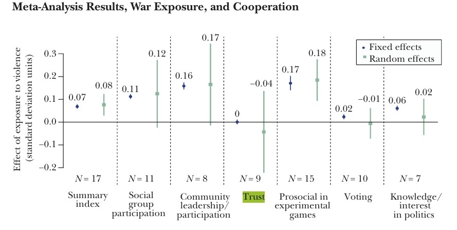

Bauer, Blattman, Chytilová, Henrich, Miguel, and Mitts, Figure 1. Effects of war exposure on cooperation.

Trust stands out. It is also conceptually different.

## In-group and out-group

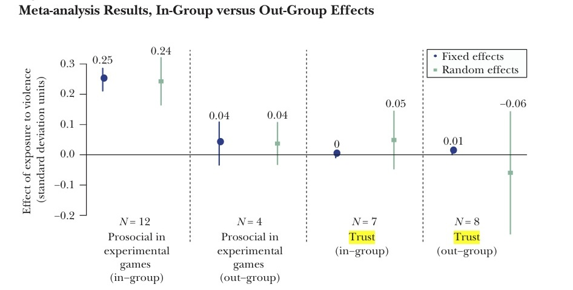

Bauer, Blattman, Chytilová, Henrich, Miguel, and Mitts, Figure 2. In-group versus out-group effects.

in-group pattern read as ‘parochial altruism.’ if so, it could harden social divisions and contribute to conflict cycles

## Lessons from the larger record

Barceló (2026) harmonizes 172 studies, across more than 50 countries, on 22 outcomes in four families

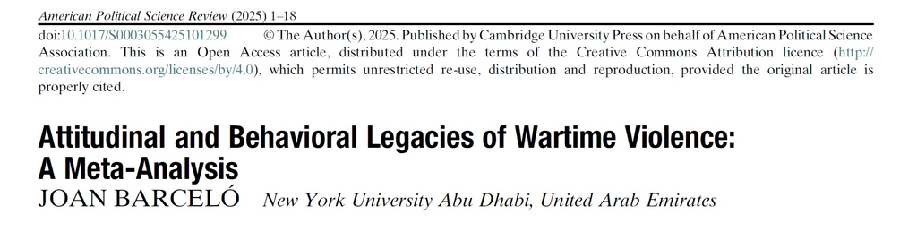

Barceló, Attitudinal and Behavioral Legacies of Wartime Violence.

Not *in*consistent with Bauer et al. (2016), though the negative implications come through much more strongly.

## Lessons from the larger record

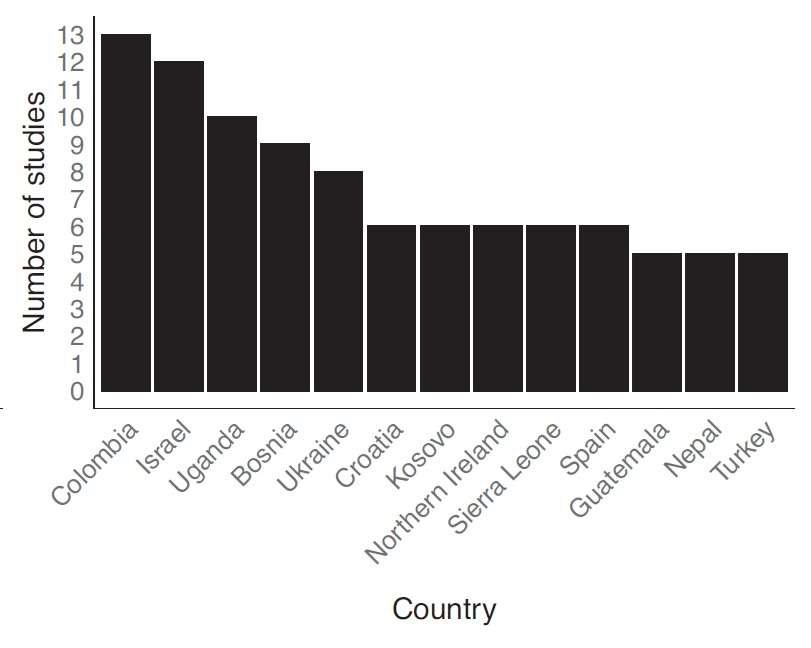

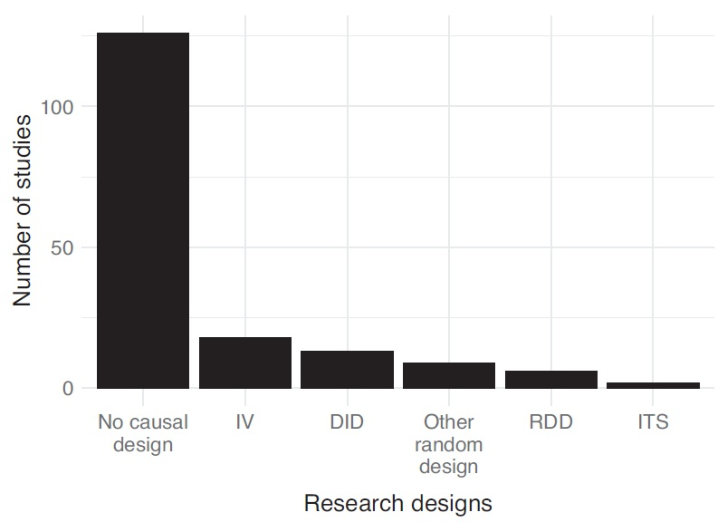

Most studies have no causal design. The headline models are bivariate.

## Participation

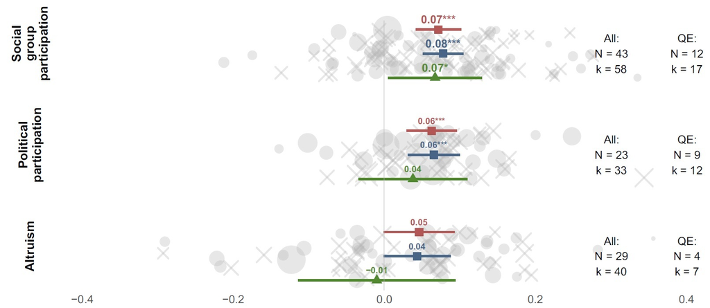

Social-group participation is about 0.07 standard deviations and holds in the quasi-experimental subset. Political participation is weaker once the design is quasi-experimental. Altruism is small, and about $-0.01$ in that subset.

## Voting and trust

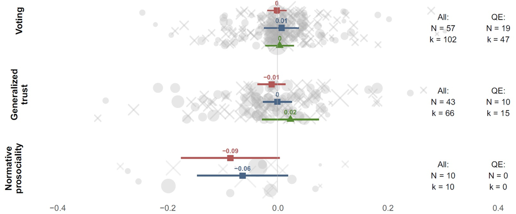

Voting and generalized trust are about zero. Normative prosociality, where it is estimated at all, leans negative, and no quasi-experimental estimate is in the figure.

## Hardening toward the old enemy

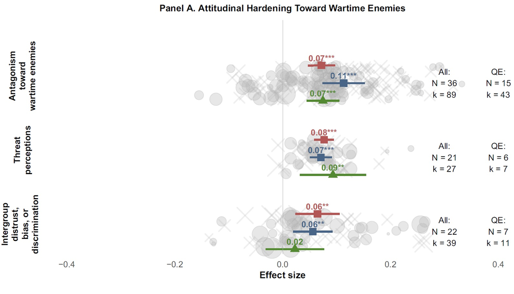

Antagonism, threat, and intergroup distrust move by about 0.06 to 0.11 standard deviations. Several of these hold in quasi-experimental studies.

## In-group identification

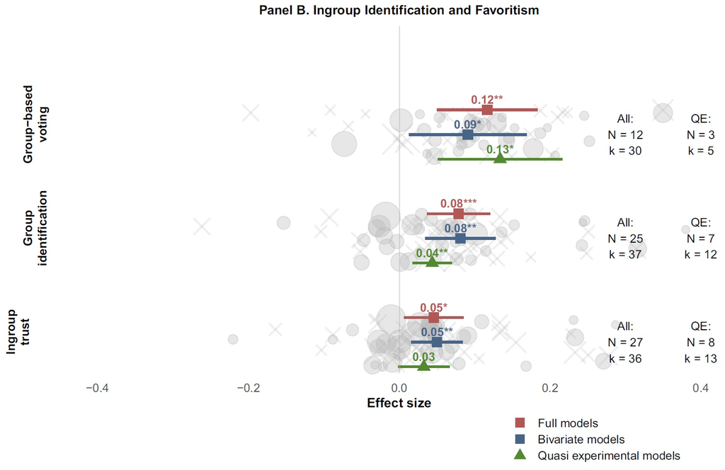

## Not a general disposition to fight

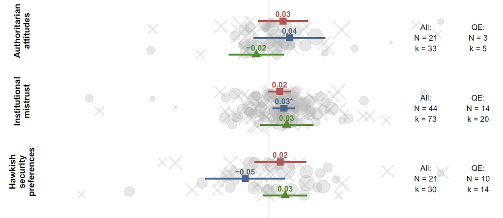

Little movement supporting *general* dispositions.

But: a *lot* of heterogeneity

## How big is 0.06 standard deviations?

Take a binary outcome with control mean $0.5$.

- An effect of 0.06 standard deviations moves the rate from `0.50` to `0.53`
- The probability that a bad outcome is due to the exposure is anywhere between `6%` and `94%` (Dawid et al. 2016). The data barely constrain individual attribution.

## Big lessons but four limits

Very very impressive aggregation work and a rich body of studies.

Still:

- The estimates are micro, not macro.
- They are small.
- They are strongest for specific outcomes not generalized psychological orientations.
- Most are not causally identified. Those that are, are often weaker

# Mechanisms

## Three ways a mark could travel

An abundance of mechanisms:

- **Biological mechanisms**: Developmental programming, in utero or in childhood.
- **Social transmission**, through families, narratives, or local practice.
- **Effects on conditions**: e.g. segregation, inequality

## Amazing mice study

Dias and Ressler (2014) fear-conditioned mice to an odor before conception

- Offspring and grand-offspring were more sensitive to that odor (social pathways blocked).
- Cue-specific sensitivity is inherited.
- But this is in line with alertness, not clearly with adverse processing effects associated with trauma.

## Epigenetic evidence not very clear for this account

Holocaust methylation results:

Bierer and coauthors compare 125 offspring with 31 controls, and a pooled sample of 147 and 40 (Bierer et al. 2020).

- FKBP5 site-6 methylation is lower in offspring, and expression is higher. The methylation difference lines up with maternal exposure in childhood, and with **lower** offspring anxiety.

So, that suggests a developmental-programming result. But not fear or obvious tie to conflict propensity.

- Yehuda and Lehrner (2018) are also reserved in claims

# Interventions

## Aid aimed inside the community

A lot of aid interventions focus on strengthening trust, or social cohesion:

- Fearon et al. (2015) study community-driven reconstruction in Liberia. Positive effects but the target is collective-action capacity inside communities
- Humphreys, Sánchez de la Sierra, and van der Windt study Tuungane in eastern Congo. The target is the same: practices inside the village (Humphreys et al. 2019).

BMZ TDA programming, two interventions are underway in conflict settings.

- One, in Nigeria, is a counselling intervention. It appears to generate prosocial activity.
- One is a local-engagement intervention. It suggests some gains also, at a local level.

Neither addresses future conflict risk.

## Reintegration in Aceh

Barron, Humphreys, Paler, and Weinstein evaluate BRA-KDP, a community-driven reintegration program in Aceh (Barron et al. 2009).

- Like the Liberia and Tuungane projects, it targets practice inside communities.
- If anything, it led to less acceptance of former combatants.

## PTSD interventions 1

Robjant et al. (2019) randomize 92 female former child soldiers with PTSD in eastern Congo to adapted narrative exposure therapy or treatment as usual

- At nine months, Cohen’s $d$ is about $-2.0$ for PTSD symptoms, $-1.0$ for appetitive aggression, and $-1.1$ for violent behavior in the past three months.
- This is a large effect among people who had perpetrated violence.
- The outcome is local violence (not the onset of a war).

Excellent study.

## PTSD interventions 2

Pham et al. (2004) in four Rwandan communes, find that PTSD symptom criteria go with **less** support for national trials, less belief in community, and less interdependence across ethnic groups

- Reconciliation interventions may be most difficult among those that need them most

# Back to war: A thought

## Aggregation logics

The path from individual responses to social outcomes is often not direct Humphreys and Scacco (2020)

- **Simple aggregation**: Walter style simple aggregation (Walter 2004) — if individuals are more conflict prone society or more hostile to out there conflict will occur directly
- Social agggregation: **Social norm change**: Canetti et al. (2017)
- Indirect aggregtation or **effects via leaders**

## Strategic logics

Strategic accounts of conflict often do not focus on psychological factors (or individual orientations broadly).

- But they *do* focus on decision making by individuals (leaders)
- They focus often on logics of bargaining and bargaining failure.
- And here there are at least four connections

## Strategic logics

Four connections:

- **Grievance**, in Gurr’s sense, is a group’s reading of relative deprivation and of its capacity to act (Gurr 1970). Trauma would have to change that reading, or that capacity.
- Fearon (1995) highlights **commitment** problems. Possible connections here to trauma, e.g. in the work of Máté (Pierre Boulez Saal 2024).
- Fearon (1995) also highlights **uncertainty**; a psychological state would matter if it stopped actors from absorbing information, or gave them a reason to conceal what they know.
- Jervis (1976) highlights **misperceptions**: a psychological state would matter if it changed what leaders believe the other side wants, or what they believe their own actions signal.

## Strategic logics

So can we address this at the level of a leader?

- Could trauma, guilt, or an inherited historical obligation shift how a leader handles misperception, a commitment problem, or uncertainty?
- I don’t know studies focusing on this; but sounds promising

# Close

## Where we are

Theoretically and empirically rich agenda

- Plenty of micro studies
- Much weaker understanding of aggregate outcomes

To treat trauma as a cause of future conflict, one would need:

- evidence about trauma itself rather than about having lived through violence
- a mechanism that aggregates: is the effect via leaders directly or indirectly via aggregate demand or via social norms
- exclusion of the many social pathways

# Extra slides

## A heartfelt position

On 11 October 2023, then Vice Chancellor Robert Habeck connected the Hamas attacks immediately to German violence against Jews and underlined Germany’s responsibility (Habeck 2023).

He said Germany would support Israel wherever that support is needed: *wir werden es dabei unterstützen, wo immer es unsere Unterstützung braucht.*

The position is heartfelt. It is disconnected from recognizably ethical principles. It is about a debt.

[The video](https://www.youtube.com/watch?v=LLi_ycT1rGw).

## His own account of why

*Welt* reports Habeck’s account: coming to terms with the guilt of his great-grandfather and his grandfather still places him under a political obligation (Welt 2024).

## Memory moves emotion. Attitudes are imprecise.

Balcells and Voytas find strong emotional responses to the Troubles and Beyond exhibit, in the museum and in a survey experiment (Balcells and Voytas 2026).

Attitude estimates sit near zero. The largest cleavage effect they highlight is $d = 0.12$.

Figure 2 intervals run into several tenths of a standard deviation. That range includes the effects they found in a Chile museum study, about $0.21$ to $0.27$ (Balcells et al. 2022), and it is larger than Barceló’s pooled estimates (Barceló 2026).

The attitude result is an imprecise null. It is not a precise zero.

## Stolpersteine: emotion, or a vote, not a mechanism from trauma

- Türkoglu, Ditlmann, and Firestone estimate about a 1 percentage point lower AfD vote share after local placement (Türkoglu et al. 2023). They do not estimate a psychological mediator. They discuss visibility, moral emotion, and local social practices.
- Ruipérez Núñez and Sauter show photographs of the stones. Anger, disgust, sadness, hostility, and fear rise. Pride and joy fall, from about $0.17$ standard deviations for fear to $-0.91$ for joy. Tolerance and most attitudes do not move. Right-leaning respondents become more negative toward refugees (Ruipérez Núñez and Sauter 2026).

## Contact reaches peers

- Scacco and Warren, in Kaduna, find no change in prejudice after sixteen weeks in mixed classes. Mixed-class subjects discriminate less. Homogeneous classes may discriminate more (Scacco and Warren 2018).
- Mousa assigns displaced Iraqi Christians to mixed or all-Christian soccer teams. Tolerant behavior rises toward Muslim peers on the team. It does not extend to Muslim strangers, and attitudes do not move consistently (Mousa 2020).

## References

Balcells, Laia, Valeria Palanza, and Elsa Voytas. 2022. “Do Transitional Justice Museums Persuade Visitors? Evidence from a Field Experiment.” *Journal of Politics* 84 (1). https://doi.org/10.1086/714765.

Balcells, Laia, and Elsa Voytas. 2026. “The Troubles and Beyond: The Impact of a Museum Exhibit on a Post-Conflict Society.” *American Journal of Political Science* 70 (3): 1146–63. https://doi.org/10.1111/ajps.70001.

Barceló, Joan. 2026. “Attitudinal and Behavioral Legacies of Wartime Violence: A Meta-Analysis.” *American Political Science Review* 120 (3): 982–99. https://doi.org/10.1017/S0003055425101299.

Barron, Patrick, Macartan Humphreys, Laura Paler, and Jeremy Weinstein. 2009. *Community-Based Reintegration in Aceh: Assessing the Impacts of BRA-KDP*. Indonesian Social Development Paper No. 12. https://macartan.github.io/assets/pdf/papers/2009_bhpw-bra-kdp.pdf.

Bauer, Michal, Christopher Blattman, Julie Chytilová, Joseph Henrich, Edward Miguel, and Tamar Mitts. 2016. “Can War Foster Cooperation?” *Journal of Economic Perspectives* 30 (3): 249–74. https://doi.org/10.1257/jep.30.3.249.

Bierer, Linda M., Heather N. Bader, Nikolaos P. Daskalakis, et al. 2020. “Intergenerational Effects of Maternal Holocaust Exposure on FKBP5 Methylation.” *American Journal of Psychiatry* 177 (8): 744–53. https://doi.org/10.1176/appi.ajp.2019.19060618.

Canetti, Daphna, Julia Elad-Strenger, Iris Lavi, Dana Guy, and Daniel Bar-Tal. 2017. “Exposure to Violence, Ethos of Conflict, and Support for Compromise.” *Journal of Conflict Resolution* 61 (1): 84–113. https://doi.org/10.1177/0022002715569771.

Dawid, A. Philip, Monica Musio, and Stephen E. Fienberg. 2016. “From Statistical Evidence to Evidence of Causality.” *Bayesian Analysis* 11 (3): 725–52. https://doi.org/10.1214/15-BA968.

Dias, Brian G., and Kerry J. Ressler. 2014. “Parental Olfactory Experience Influences Behavior and Neural Structure in Subsequent Generations.” *Nature Neuroscience* 17 (1): 89–96. https://doi.org/10.1038/nn.3594.

Fearon, James D. 1995. “Rationalist Explanations for War.” *International Organization* 49 (3): 379–414. https://www.jstor.org/stable/2706903.

Fearon, James D., Macartan Humphreys, and Jeremy M. Weinstein. 2015. “How Does Development Assistance Affect Collective Action Capacity? Results from a Field Experiment in Post-Conflict Liberia.” *American Political Science Review* 109 (3): 450–69. https://doi.org/10.1017/S0003055415000283.

Grossman, Guy, Devorah Manekin, and Dan Miodownik. 2015. “The Political Legacies of Combat: Attitudes Toward War and Peace Among Israeli Ex-Combatants.” *International Organization* 69 (4): 981–1009. https://doi.org/10.1017/S002081831500020X.

Gurr, Ted Robert. 1970. *Why Men Rebel*. Princeton University Press. https://archive.org/details/whymenrebel00gurr.

Habeck, Robert. 2023. “Address on the Hamas Attacks and Germany’s Responsibility.” https://www.youtube.com/watch?v=LLi_ycT1rGw.

Hadzic, Dino, David Carlson, and Margit Tavits. 2020. “How Exposure to Violence Affects Ethnic Voting.” *British Journal of Political Science* 50 (1): 345–62. https://doi.org/10.1017/S0007123417000448.

Hirsch-Hoefler, Sivan, Daphna Canetti, Carmit Rapaport, and Stevan E. Hobfoll. 2016. “Conflict Will Harden Your Heart: Exposure to Violence, Psychological Distress, and Peace Barriers in Israel and Palestine.” *British Journal of Political Science* 46 (4): 845–59. https://doi.org/10.1017/S0007123414000374.

Humphreys, Macartan, Raúl Sánchez de la Sierra, and Peter van der Windt. 2019. “Exporting Democratic Practices: Evidence from a Village Governance Intervention in Eastern Congo.” *Journal of Development Economics* 140: 279–301. https://doi.org/10.1016/j.jdeveco.2019.03.011.

Humphreys, Macartan, and Alexandra Scacco. 2020. “The Aggregation Challenge.” *World Development* 127: 104806. https://doi.org/10.1016/j.worlddev.2019.104806.

Jervis, Robert. 1976. *Perception and Misperception in International Politics*. Princeton University Press. https://press.princeton.edu/books/hardcover/9780691177434/perception-and-misperception-in-international-politics.

Lindsey, Summer. 2022. “Conflict, Protection, and Punishment: Repercussions of Violence in Eastern DR Congo.” *American Journal of Political Science* 66 (1): 187–204. https://doi.org/10.1111/ajps.12637.

Lindsey, Summer, and Carlo Koos. 2025. “Legacies of Wartime Sexual Violence: Survivors, Psychological Harms, and Mobilization.” *American Political Science Review* 119 (2): 653–69. https://doi.org/10.1017/S000305542400042X.

MacManus, Deirdre, Kimberlie Dean, Margaret Jones, et al. 2013. “Violent Offending by UK Military Personnel Deployed to Iraq and Afghanistan: A Data Linkage Cohort Study.” *The Lancet* 381 (9870): 907–17. https://doi.org/10.1016/S0140-6736(13)60354-2.

Mousa, Salma. 2020. “Building Social Cohesion Between Christians and Muslims Through Soccer in Post-ISIS Iraq.” *Science* 369 (6505): 866–70. https://doi.org/10.1126/science.abb3153.

Narciso, Gaia, and Battista Severgnini. 2023. “The Deep Roots of Rebellion.” *Journal of Development Economics* 160: 102952. https://doi.org/10.1016/j.jdeveco.2022.102952.

Pham, Phuong N., Harvey M. Weinstein, and Timothy Longman. 2004. “Trauma and PTSD Symptoms in Rwanda: Implications for Attitudes Toward Justice and Reconciliation.” *JAMA* 292 (5): 602–12. https://doi.org/10.1001/jama.292.5.602.

Pierre Boulez Saal. 2024. “Wasmuth Lecture: Traumata in Israel and Palestine. Gabor Maté in Conversation with Macartan Humphreys.” https://www.boulezsaal.de/en/event/wasmuth-lecture-406680.

Robjant, Katy, Anke Koebach, Sabine Schmitt, Amani Chibashimba, Samuel Carleial, and Thomas Elbert. 2019. “The Treatment of Posttraumatic Stress Symptoms and Aggression in Female Former Child Soldiers Using Adapted Narrative Exposure Therapy: A Randomized Controlled Trial in Eastern Democratic Republic of Congo.” *Behaviour Research and Therapy* 123: 103482. https://doi.org/10.1016/j.brat.2019.103482.

Ruipérez Núñez, Ana, and Melanie Sauter. 2026. “Can Monuments to Victims Increase Tolerance?” *Journal of Experimental Political Science* 13 (1): 1–14. https://doi.org/10.1017/XPS.2025.10022.

Scacco, Alexandra, and Shana S. Warren. 2018. “Can Social Contact Reduce Prejudice and Discrimination? Evidence from a Field Experiment in Nigeria.” *American Political Science Review* 112 (3): 654–77. https://doi.org/10.1017/S0003055418000151.

Taylor, Emmeline N., Christine Timko, Amia Nash, Mandy D. Owens, Alex H. S. Harris, and Andrea K. Finlay. 2020. “Posttraumatic Stress Disorder and Justice Involvement Among Military Veterans: A Systematic Review and Meta-Analysis.” *Journal of Traumatic Stress* 33 (5): 804–12. https://doi.org/10.1002/jts.22526.

Türkoglu, Oğuzhan, Ruth Ditlmann, and Berenike Firestone. 2023. “Commemorating Local Victims of Past Atrocities and Far-Right Support over Time.” *Proceedings of the National Academy of Sciences* 120 (28): e2221158120. https://doi.org/10.1073/pnas.2221158120.

Walter, Barbara F. 2004. “Does Conflict Beget Conflict? Explaining Recurring Civil War.” *Journal of Peace Research* 41 (3): 371–88. https://doi.org/10.1177/0022343304043775.

Welt. 2024. “Nazi-Vergangenheit: Habeck Spricht Über Schuld Seiner Großväter.” https://www.welt.de/vermischtes/prominente/article252098570/Nazi-Vergangenheit-Habeck-spricht-ueber-Schuld-seiner-Grossvaeter.html.

Yehuda, Rachel, and Amy Lehrner. 2018. “Intergenerational Transmission of Trauma Effects: Putative Role of Epigenetic Mechanisms.” *World Psychiatry* 17 (3): 243–57. https://doi.org/10.1002/wps.20568.